# Integrated Step-Selection Analyses Using amt

jfieberg

2023-03-10

Author: Brian J. Smith brian.smith@usu.edu (with minor modifications by John Fieberg)

## Preamble

Load packages

```r
library(amt)
library(terra)
library(sf)
library(dplyr)
library(ggplot2)
library(lubridate)
```

Load GPS data (Demo data included in ‘amt’)

```r
gps <- uhc_issf_locs
```

Load habitat data (Demo data included in ‘amt’)

```r
hab <- uhc_hab
```

Convert to a raster

```r
hab <- rast(uhc_hab, type = "xyz", crs = "epsg:32612")
```

Convert “cover” layer to factor

```r
levels(hab[[4]]) <- data.frame(id = 1:3,
                               cover = c("grass", "forest", "wetland"))
```

Quick look

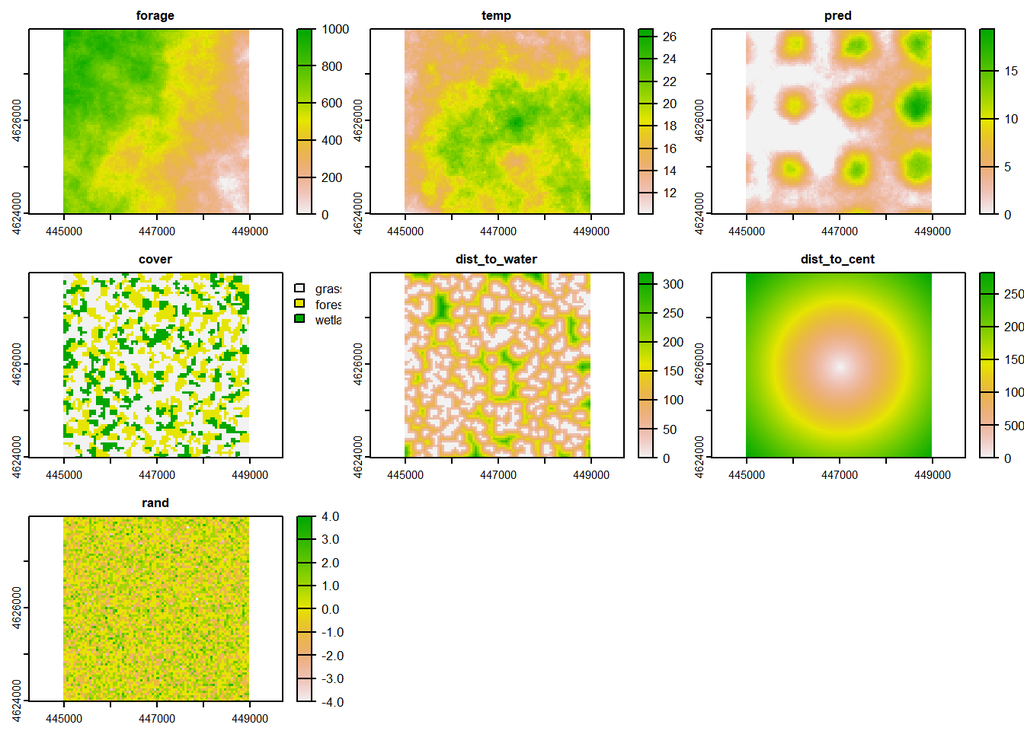

```r
plot(hab)
```

## Basics of ‘amt’

The basic building block in the package `amt` is a `track_*` object. For movement data, this is a `track_xyt` object, but locations without timestamps are also possible (`track_xy`). We can format our data as a `track_*` object using `make_track()`.

```r
trk <- make_track(gps, .x = x, .y = y, t. = t, crs = 32612)
```

We can see the class of the resulting object

```r
class(trk)
```

```
## [1] "track_xy"   "tbl_df"     "tbl"        "data.frame"
```

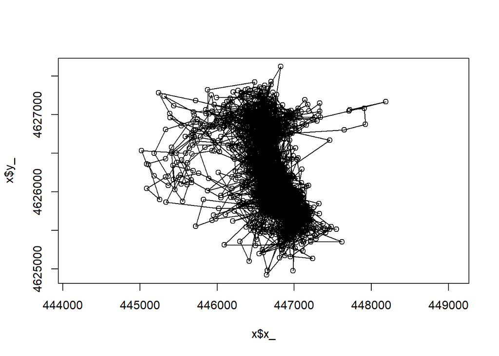

```r
plot(trk)
lines(trk)
```

Or, on top of our raster:

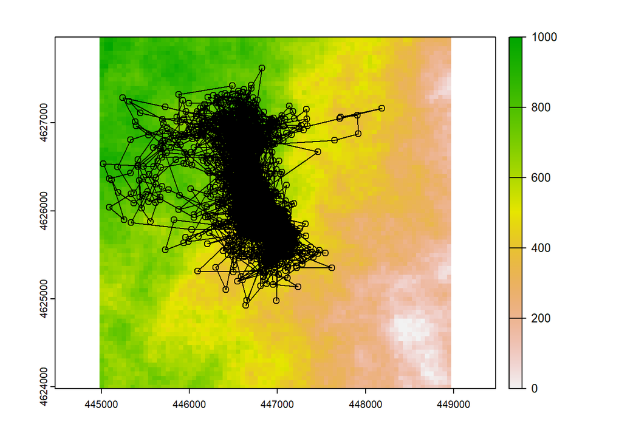

```r
plot(hab[[1]])
points(trk)
lines(trk)
```

## iSSFs in ‘amt’

### Creating steps

While the most basic building block in ‘amt’ is a track, iSSA requires that we convert from a point representation to a step representation. We can do that with the function `steps()`.

```r
stp <- gps %>%
  make_track(x, y, t, crs = 32612) %>%
  steps()
# View(stp)
```

Note that steps have their own S3 class:

```r
class(stp)
```

```
## [1] "steps_xyt"  "steps_xy"   "tbl_df"     "tbl"        "data.frame"
```

Data cleaning is an important first step whenever you’re working with GPS data. Unfortunately, we did not allocate time today to dive into the details of data cleaning. We have data cleaning functions in ‘amt’, and we will soon have a new vignette with a demonstrated cleaning workflow. Once your data are cleaned, you will often have gaps in an otherwise regular trajectory. iSSA requires a constant step duration, so we cannot create steps across gaps in our data. To simulate gaps, we will randomly remove ~5% of the locations:

```r
set.seed(12345)
trk2 <- gps %>%
  make_track(x, y, t, crs = 32612) %>%
  mutate(rm = as.logical(rbinom(n = nrow(.), size = 1, prob = 0.05))) %>%
  filter(!rm)
```

Check

```r
nrow(trk2)/nrow(gps)
```

```
## [1] 0.9461358
```

```r
print(trk2, n = 10)
```

```
## # A tibble: 2,020 × 4
##         x_       y_ t_                  rm
##  *   <dbl>    <dbl> <dttm>              <lgl>
##  1 446975  4625975  2021-02-15 00:00:00 FALSE
##  2 446975  4626025  2021-02-15 01:00:00 FALSE
##  3 446705. 4626378. 2021-02-15 02:00:00 FALSE
##  4 446870. 4625955. 2021-02-15 03:00:00 FALSE
##  5 446809. 4626028. 2021-02-15 04:00:00 FALSE
##  6 446667. 4626046. 2021-02-15 05:00:00 FALSE
##  7 446400. 4626390. 2021-02-15 06:00:00 FALSE
##  8 446533. 4626811. 2021-02-15 07:00:00 FALSE
##  9 446540. 4627013. 2021-02-15 08:00:00 FALSE
## 10 446681. 4626544. 2021-02-15 10:00:00 FALSE
## # … with 2,010 more rows
```

Notice we removed our 10th location – we have a 2h gap from 2021-02-15 08:00 to 2021-02-15 10:00.

What happens if we make steps, now?

```r
stp2 <- steps(trk2)
# View(stp2)
```

We now have some steps where dt = 2 hours. Our trajectory is irregular, and that will not work for iSSA. We can filter out those 2 hour steps fairly easily in this simplified example, but a more useful way to deal with this is to use the function `track_resample()`.

`track_resample()` takes the track, the desired duration, and a tolerance around that duration as arguments, then it divides a trajectory into “bursts” with a constant step duration. Note, this function doesn’t do any interpolation.

```r
trk3 <- track_resample(trk2, rate = hours(1), tolerance = minutes(5))
print(trk3, n = 12)
```

```
## # A tibble: 2,020 × 5
##         x_       y_ t_                  rm    burst_
##  *   <dbl>    <dbl> <dttm>              <lgl>  <dbl>
##  1 446975  4625975  2021-02-15 00:00:00 FALSE      1
##  2 446975  4626025  2021-02-15 01:00:00 FALSE      1
##  3 446705. 4626378. 2021-02-15 02:00:00 FALSE      1
##  4 446870. 4625955. 2021-02-15 03:00:00 FALSE      1
##  5 446809. 4626028. 2021-02-15 04:00:00 FALSE      1
##  6 446667. 4626046. 2021-02-15 05:00:00 FALSE      1
##  7 446400. 4626390. 2021-02-15 06:00:00 FALSE      1
##  8 446533. 4626811. 2021-02-15 07:00:00 FALSE      1
##  9 446540. 4627013. 2021-02-15 08:00:00 FALSE      1
## 10 446681. 4626544. 2021-02-15 10:00:00 FALSE      2
## 11 446847. 4627126. 2021-02-15 11:00:00 FALSE      2
## 12 446240. 4626595. 2021-02-15 12:00:00 FALSE      2
## # … with 2,008 more rows
```

We have a new column, `burst_`, that identifies our bursts. We can see the switch from burst 1 to burst 2 after our gap at 10:00. If we pass that to `steps()`, we now get a warning:

```r
steps(trk3)
```

```
## Warning in steps.track_xyt(trk3): burst's are ignored, use
## steps_by_burst instead.
```

```
## # A tibble: 2,019 × 10
##        x1_     x2_    y1_    y2_   sl_ direc…¹    ta_ t1_
##      <dbl>   <dbl>  <dbl>  <dbl> <dbl>   <dbl>  <dbl> <dttm>
##  1 446975  446975  4.63e6 4.63e6  50      1.57 NA     2021-02-15 00:00:00
##  2 446975  446705. 4.63e6 4.63e6 445.     2.22  0.652 2021-02-15 01:00:00
##  3 446705. 446870. 4.63e6 4.63e6 454.    -1.20  2.86  2021-02-15 02:00:00
##  4 446870. 446809. 4.63e6 4.63e6  95.8    2.27 -2.82  2021-02-15 03:00:00
##  5 446809. 446667. 4.63e6 4.63e6 143.     3.02  0.749 2021-02-15 04:00:00
##  6 446667. 446400. 4.63e6 4.63e6 435.     2.23 -0.785 2021-02-15 05:00:00
##  7 446400. 446533. 4.63e6 4.63e6 442.     1.27 -0.966 2021-02-15 06:00:00
##  8 446533. 446540. 4.63e6 4.63e6 202.     1.54  0.270 2021-02-15 07:00:00
##  9 446540. 446681. 4.63e6 4.63e6 489.    -1.28 -2.81  2021-02-15 08:00:00
## 10 446681. 446847. 4.63e6 4.63e6 605.     1.29  2.57  2021-02-15 10:00:00
## # … with 2,009 more rows, 2 more variables: t2_ <dttm>, dt_ <drtn>, and
## #   abbreviated variable name ¹direction_p
```

The warning tells us to use `steps_by_burst()` to make use of the new column:

```r
stp3 <- steps_by_burst(trk3)
# View(stp3)
```

We no longer have any steps with 2-h durations, and we are ready to proceed with our iSSA.

### Movement parameters and random steps

The next thing we need to do is generate random available steps from a tentative parametric distribution. We will use the gamma distribution to generate step lengths and a von Mises distribution to generate turn angles. After fitting our iSSA, we will update these tentative distributions to the true, selection-free movement distributions. A good way to decide on tentative parameters is to fit them to observed steps. We can do that in `amt` like this: gamma distribution (fit to step lengths)

```r
(sldist <- fit_distr(stp3$sl_, "gamma"))
```

```
## $name
## [1] "gamma"
##
## $params
## $params$shape
## [1] 4.729899
##
## $params$scale
## [1] 68.25348
##
##
## $vcov
##            scale       shape
## scale  5.0736913 -0.31587740
## shape -0.3158774  0.02188948
##
## attr(,"class")
## [1] "gamma_distr" "sl_distr"    "amt_distr"   "list"
```

von Mises distribution (fit to turn angles)

```r
(tadist <- fit_distr(stp3$ta_, "vonmises"))
```

```
## $name
## [1] "vonmises"
##
## $params
## $params$kappa
## [1] 0.06168608
##
## $params$mu
## Circular Data:
## Type = angles
## Units = radians
## Template = none
## Modulo = asis
## Zero = 0
## Rotation = counter
## [1] 0
##
##
## $vcov
##            [,1]
## [1,] 0.03329244
##
## attr(,"class")
## [1] "vonmises_distr" "ta_distr"       "amt_distr"      "list"
```

We can then overlay these on the empirical step-length and turn angle distributions to see how well they match.

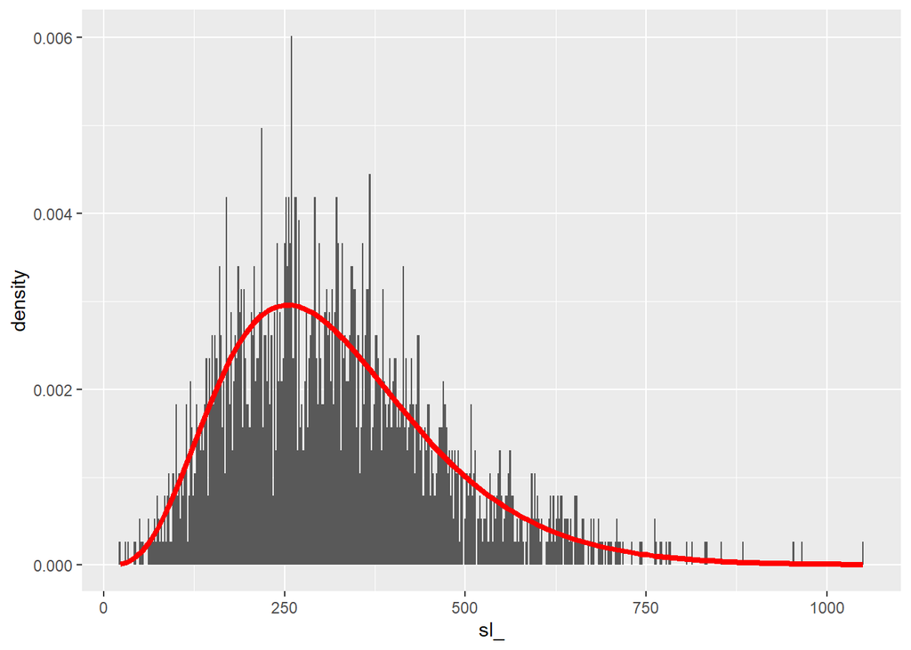

```r
ggplot(stp3, aes(x = sl_)) +
  geom_histogram(aes(y = ..density..), binwidth = 2) +
  stat_function(fun =function(x)dgamma(x, shape = sldist$params$shape,
                                        scale = sldist$params$scale),
                 color = "red", lwd=1.5)
```

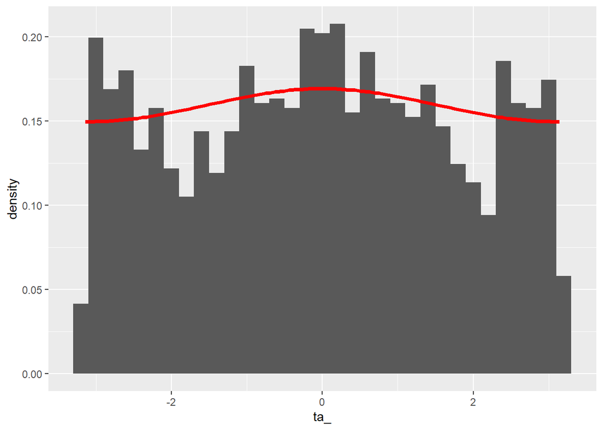

```r
ggplot(stp3, aes(x = ta_)) +
  geom_histogram(aes(y = ..density..), binwidth = 0.2) +
  stat_function(fun =function(x)circular::dvonmises(x, mu = 0, kappa = tadist$params$kappa),
                color = "red", lwd=1.5)
```

We can use the function `random_steps()` to generate our random steps. When we pass a `steps_xyt` object, the default is for it to fit the gamma and von Mises distributions, just as we did above.

```r
set.seed(20220626 + 1)
obs_avail <- random_steps(stp3, n_control = 20)
```

Random steps have their own S3 class, but they are also still of class `steps_xyt`.

```r
class(obs_avail)
```

```
## [1] "random_steps" "steps_xyt"    "steps_xy"     "tbl_df"
## [5] "tbl"          "data.frame"
```

Take a look: View(obs_avail)

Each observed step gets an identifying number (`step_id_`), and all of the paired available steps get that same ID. These IDs form the strata in our conditional logistic regression. The variable `case_` is TRUE for the observed step and `FALSE` for the available steps. This will be the response variable in our conditional logistic regression.

Note that the tentative step length and turn angle distributions are attached to the object as attributes.

```r
attributes(obs_avail)
```

[output not shown]

[output cut: 135 more lines]

[output not shown]

You can also access them with these convenience functions:

```r
sl_distr(obs_avail)
```

```
## $name
## [1] "gamma"
##
## $params
## $params$shape
## [1] 4.729899
##
## $params$scale
## [1] 68.25348
##
##
## $vcov
##            scale       shape
## scale  5.0736913 -0.31587740
## shape -0.3158774  0.02188948
##
## attr(,"class")
## [1] "gamma_distr" "sl_distr"    "amt_distr"   "list"
```

```r
ta_distr(obs_avail)
```

```
## $name
## [1] "vonmises"
##
## $params
## $params$kappa
## [1] 0.06168608
##
## $params$mu
## Circular Data:
## Type = angles
## Units = radians
## Template = none
## Modulo = asis
## Zero = 0
## Rotation = counter
## [1] 0
##
##
## $vcov
##            [,1]
## [1,] 0.03329244
##
## attr(,"class")
## [1] "vonmises_distr" "ta_distr"       "amt_distr"      "list"
```

Since we used the gamma distribution as our tentative step-length distribution, we will want to include step length and log(step length) in our iSSF. Doing so will:

- correct for bias that arises from ignoring habitat selection when estimating the movement parameters in the tenative distributions (Forester et al. 2009)
- allow us to obtain updated/improved estimates of movement parameters that adjust for habitat selection

Since we used the von Mises distribution as our tentative turn-angle distribution, we need to include cos(turn angle) in our iSSF.

### Extracting Covariates

Now that we have observed and available steps, we need to attach our environmental covariates to each one. We can use the functions ‘extract_covariates()’ to attach the raster values to our steps.

```r
covs <- extract_covariates(obs_avail, hab)
```

Have a look:

```r
print(covs, n = 3, width = 200)
```

```
## # A tibble: 37,947 × 19
##   burst_    x1_     x2_     y1_      y2_   sl_    ta_ t1_
##    <dbl>  <dbl>   <dbl>   <dbl>    <dbl> <dbl>  <dbl> <dttm>
## 1      1 446975 446705. 4626025 4626378.  445.  0.652 2021-02-15 01:00:00
## 2      1 446975 447350. 4626025 4626641.  722. -0.546 2021-02-15 01:00:00
## 3      1 446975 446467. 4626025 4626261.  560.  1.14  2021-02-15 01:00:00
##   t2_                 dt_     case_ step_id_ forage  temp  pred cover
##   <dttm>              <drtn>  <lgl>    <int>  <dbl> <dbl> <dbl> <fct>
## 1 2021-02-15 02:00:00 1 hours TRUE         2   600.  19.1 1.02  grass
## 2 2021-02-15 02:00:00 1 hours FALSE        2   447.  19.8 8.74  grass
## 3 2021-02-15 02:00:00 1 hours FALSE        2   636.  19.6 0.845 wetland
##   dist_to_water dist_to_cent  rand
##           <dbl>        <dbl> <dbl>
## 1           100         541.     0
## 2           100         783.     1
## 3             0         626.    -1
## # … with 37,944 more rows
```

One of the great strengths of iSSA is that it can handle temporal variation. Perhaps our organism selects habitat differently between day and night, or perhaps it moves with different speeds during day or night. We can account for this with interactions in our iSSF, and ‘amt’ has a function that extracts the time of day, given the coordinates and the date. I.e., it accounts for different sunset times at different latitudes on different days of the year.

```r
covs2 <- time_of_day(covs, where = "both")
```

The argument ‘where = “both”’ tells the function to extract the time of day for *both* the start of the step and the end of the step.

```r
print(covs2, n = 3, width = 200)
```

```
## # A tibble: 37,947 × 21
##   burst_    x1_     x2_     y1_      y2_   sl_    ta_ t1_
##    <dbl>  <dbl>   <dbl>   <dbl>    <dbl> <dbl>  <dbl> <dttm>
## 1      1 446975 446705. 4626025 4626378.  445.  0.652 2021-02-15 01:00:00
## 2      1 446975 447350. 4626025 4626641.  722. -0.546 2021-02-15 01:00:00
## 3      1 446975 446467. 4626025 4626261.  560.  1.14  2021-02-15 01:00:00
##   t2_                 dt_     case_ step_id_ forage  temp  pred cover
##   <dttm>              <drtn>  <lgl>    <int>  <dbl> <dbl> <dbl> <fct>
## 1 2021-02-15 02:00:00 1 hours TRUE         2   600.  19.1 1.02  grass
## 2 2021-02-15 02:00:00 1 hours FALSE        2   447.  19.8 8.74  grass
## 3 2021-02-15 02:00:00 1 hours FALSE        2   636.  19.6 0.845 wetland
##   dist_to_water dist_to_cent  rand tod_start_ tod_end_
##           <dbl>        <dbl> <dbl> <fct>      <fct>
## 1           100         541.     0 night      night
## 2           100         783.     1 night      night
## 3             0         626.    -1 night      night
## # … with 37,944 more rows
```

Now we’re ready to fit a model!

### Fitting a model

Let’s begin with a simple iSSF. We’ll model our movement-free habitat selection kernel as a function of forage and predation risk, and we’ll include all the movement parameters to update the selection-free movement kernel. Note that the `amt` function `fit_issf()` is just a wrapper for survival::clogit(). For much more information on the implementation, see the help file.

```r
#?survival::clogit

m1 <- fit_issf(covs2,
               # Response
               case_ ~
                 # Habitat
                 forage + pred +
                 # Movement
                 sl_ + log(sl_) + cos(ta_) +
                 # Stratum
                 strata(step_id_),
               # Need this later for model predictions
               model = TRUE)
```

Let’s have a look at the structure of our object.

```r
str(m1, 1)
```

```
## List of 4
##  $ model:List of 23
##   ..- attr(*, "class")= chr [1:2] "clogit" "coxph"
##  $ sl_  :List of 3
##   ..- attr(*, "class")= chr [1:4] "gamma_distr" "sl_distr" "amt_distr" "list"
##  $ ta_  :List of 3
##   ..- attr(*, "class")= chr [1:4] "vonmises_distr" "ta_distr" "amt_distr" "list"
##  $ more : NULL
##  - attr(*, "class")= chr [1:2] "fit_clogit" "list"
```

Notice that it is a list with 4 elements at the top level.

- $model: the actual fitted model
- $sl_: the tentative step-length distribution
- $ta_: the tentative turn-angle distribution
- $more: (currently empty) a placeholder for additional information

### Model interpretation

Take a look at the model summary:

```r
summary(m1)
```

```
## Call:
## coxph(formula = Surv(rep(1, 37947L), case_) ~ forage + pred +
##     sl_ + log(sl_) + cos(ta_) + strata(step_id_), data = data,
##     model = TRUE, method = "exact")
##
##   n= 37893, number of events= 1807
##    (54 observations deleted due to missingness)
##
##                coef  exp(coef)   se(coef)       z Pr(>|z|)
## forage    0.0005935  1.0005936  0.0002184   2.717  0.00658 **
## pred     -0.3820027  0.6824932  0.0210838 -18.118  < 2e-16 ***
## sl_       0.0006723  1.0006725  0.0005114   1.314  0.18868
## log(sl_)  0.0797178  1.0829814  0.1574080   0.506  0.61255
## cos(ta_)  0.0922673  1.0966579  0.0339469   2.718  0.00657 **
## ---
## Signif. codes:  0 '***' 0.001 '**' 0.01 '*' 0.05 '.' 0.1 ' ' 1
##
##          exp(coef) exp(-coef) lower .95 upper .95
## forage      1.0006     0.9994    1.0002    1.0010
## pred        0.6825     1.4652    0.6549    0.7113
## sl_         1.0007     0.9993    0.9997    1.0017
## log(sl_)    1.0830     0.9234    0.7955    1.4744
## cos(ta_)    1.0967     0.9119    1.0261    1.1721
##
## Concordance= 0.653  (se = 0.007 )
## Likelihood ratio test= 602.5  on 5 df,   p=<2e-16
## Wald test            = 343.8  on 5 df,   p=<2e-16
## Score (logrank) test = 405.6  on 5 df,   p=<2e-16
```

Main take-aways from this summary are:

1. our animal selects for forage (+ coef)
2. our animal avoids predation risk (- coef)
3. our tentative step-length distribution is very close to the estimated selection-free movement kernel (none of the sl_ params are significant.)
4. our tentative turn-angle distribution is different from the estimated selection-free movement kernel (cos(ta_) param is significant)

With this simple model structure, we have an ‘amt’ function that will automatically update the movement distributions.

### Updating movement parameters

Tentative step-length distribution

```r
(tent_sl <- sl_distr(m1))
```

```
## $name
## [1] "gamma"
##
## $params
## $params$shape
## [1] 4.729899
##
## $params$scale
## [1] 68.25348
##
##
## $vcov
##            scale       shape
## scale  5.0736913 -0.31587740
## shape -0.3158774  0.02188948
##
## attr(,"class")
## [1] "gamma_distr" "sl_distr"    "amt_distr"   "list"
```

Updated selection-free step-length distribution

```r
(upd_sl <- update_sl_distr(m1,  beta_sl = "sl_", beta_log_sl = "log(sl_)"))
```

```
## $name
## [1] "gamma"
##
## $params
## $params$shape
## [1] 4.809616
##
## $params$scale
## [1] 71.53593
##
##
## $vcov
## NULL
##
## attr(,"class")
## [1] "gamma_distr" "sl_distr"    "amt_distr"   "list"
```

Compile the parameters into a data.frame for plotting with ggplot

```r
tent_df <- data.frame(dist = "tent",
                      shp = tent_sl$params$shape,
                      scl = tent_sl$params$scale)
upd_df <- data.frame(dist = "upd",
                     shp = upd_sl$params$shape,
                     scl = upd_sl$params$scale)

(sl_df <- rbind(tent_df, upd_df))
```

```
##   dist      shp      scl
## 1 tent 4.729899 68.25348
## 2  upd 4.809616 71.53593
```

Plot

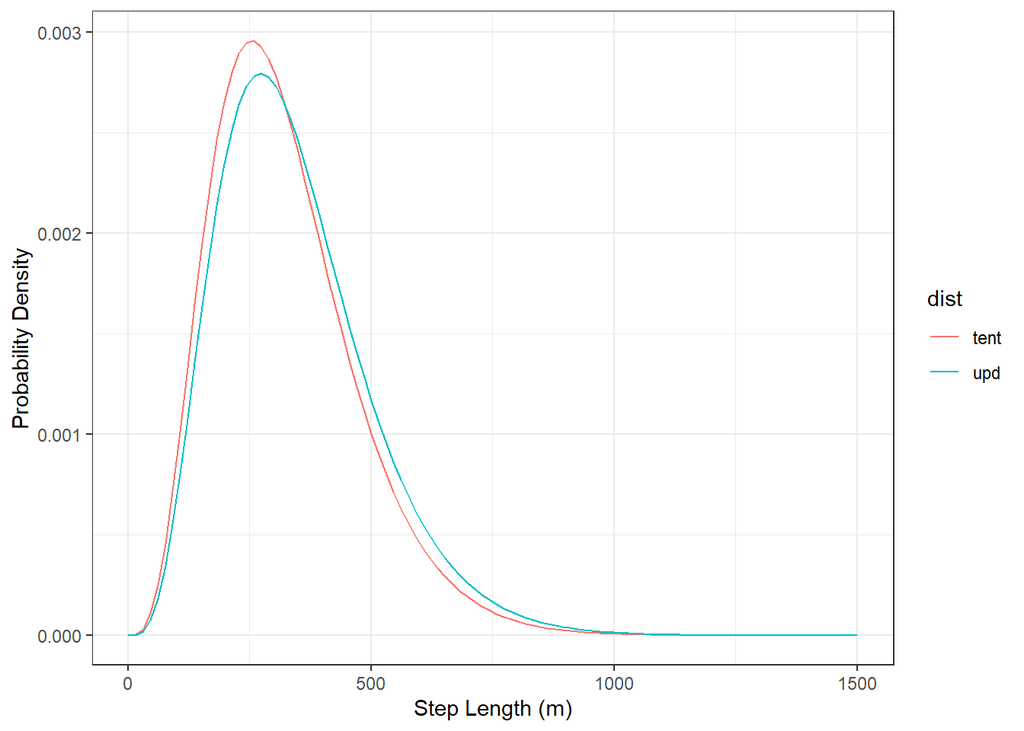

```r
expand.grid(sl = seq(1, 1500, length.out = 100),
            dist = c("tent", "upd")) %>%
  left_join(sl_df) %>%
  mutate(y = dgamma(sl, shape = shp, scale = scl)) %>%
  ggplot(aes(x = sl, y = y, color = dist)) +
  geom_line() +
  xlab("Step Length (m)") +
  ylab("Probability Density") +
  theme_bw()
```

We can see there is barely a difference between our tentative and updated step-length distributions. This is no surprise, given that the betas for sl_ and log(sl_) were not significant. Tentative turn-angle distribution

```r
(tent_ta <- ta_distr(m1))
```

```
## $name
## [1] "vonmises"
##
## $params
## $params$kappa
## [1] 0.06168608
##
## $params$mu
## Circular Data:
## Type = angles
## Units = radians
## Template = none
## Modulo = asis
## Zero = 0
## Rotation = counter
## [1] 0
##
##
## $vcov
##            [,1]
## [1,] 0.03329244
##
## attr(,"class")
## [1] "vonmises_distr" "ta_distr"       "amt_distr"      "list"
```

Updated selection-free turn-angle distribution

```r
(upd_ta <- update_ta_distr(m1, beta_cos_ta = "cos(ta_)"))
```

```
## $name
## [1] "vonmises"
##
## $params
## $params$kappa
## [1] 0.1539534
##
## $params$mu
## Circular Data:
## Type = angles
## Units = radians
## Template = none
## Modulo = asis
## Zero = 0
## Rotation = counter
## [1] 0
##
##
## $vcov
## NULL
##
## attr(,"class")
## [1] "vonmises_distr" "ta_distr"       "amt_distr"      "list"
```

Compile the parameters into a data.frame for plotting with ggplot

```r
tent_df_ta <- data.frame(dist = "tent",
                         mu = tent_ta$params$mu,
                         k = tent_ta$params$kappa)
upd_df_ta <- data.frame(dist = "upd",
                        mu = upd_ta$params$mu,
                        k = upd_ta$params$kappa)
```

Sometimes, your kappa may be negative. The von Mises is not defined for negative kappa. Negative kappa indicates that the turns are not actually concentrated around 0 (as we typically assume), but rather are concentrated around +/- pi. If this happens, we can simply multiply the estimated kappa by -1 and change mu to pi.

```r
#upd_df_ta <- data.frame(dist = "upd",
#                        mu = pi,
#                        k = -1 * upd_ta$params$kappa)

(ta_df <- rbind(tent_df_ta, upd_df_ta))
```

```
##   dist mu          k
## 1 tent  0 0.06168608
## 2  upd  0 0.15395338
```

Plot

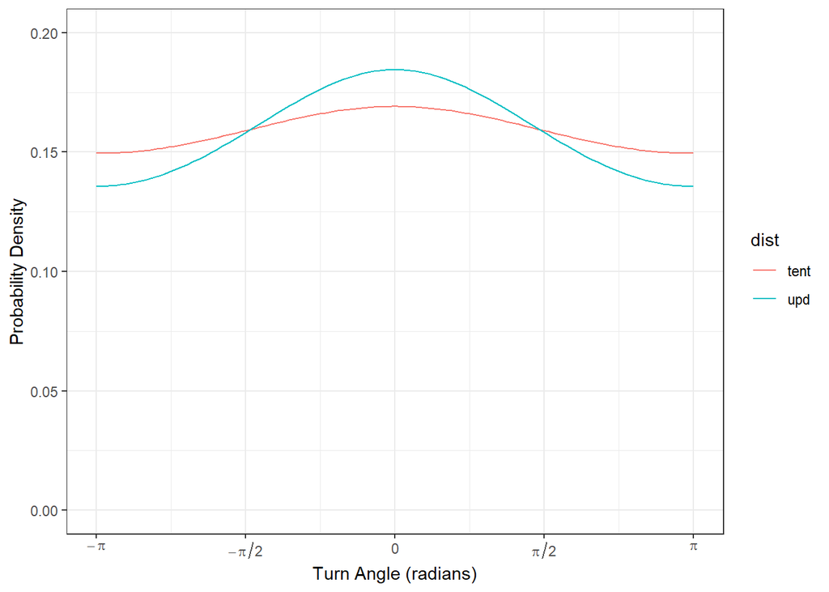

```r
expand.grid(ta = seq(-pi, pi, length.out = 100),
            dist = c("tent", "upd")) %>%
  left_join(ta_df) %>%
  # circular::dvonmises is not vectorized
  rowwise() %>%
  mutate(y = circular::dvonmises(ta, mu = mu, kappa = k)) %>%
  ggplot(aes(x = ta, y = y, color = dist)) +
  geom_line() +
  xlab("Turn Angle (radians)") +
  ylab("Probability Density") +
  scale_x_continuous(breaks = c(-pi, -pi/2, 0, pi/2, pi),
                     labels = expression(-pi, -pi/2, 0, pi/2, pi)) +
  coord_cartesian(ylim = c(0, 0.2)) +
  theme_bw()
```

As we expected, we see a difference here.

### Log relative selection strength

We can use (log-)RSS to visualize the habitat selection part of the model. We can use ‘amt::log_rss()’ to compare 2 (or more) locations, with one of the locations serving as a reference location. Both x1 and x2 are defined using data.frames and require all of the covariates in the fitted model. x1 can be any number of rows you wish, but to avoid unintended issues with R’s recycling rules, we limit x2 to be exactly 1 row.

#### Scenario 1:

How much more likely is our animal to step into a habitat with forage = 600 g/m^2 than a habitat with forage = 400 g/m^2, assuming both locations are equally accessible (i.e., equally far away from the current location)?

```r
x1 <- data.frame(forage = 600, pred = 0,
                 sl_ = 50, ta_ = 0)

x2 <- data.frame(forage = 400, pred = 0,
                 sl_ = 50, ta_ = 0)

logRSS <- log_rss(m1, x1 = x1, x2 = x2, ci = "se")
```

RSS

```r
exp(logRSS$df[, c("log_rss", "lwr", "upr")])
```

```
##    log_rss      lwr      upr
## 1 1.126023 1.033639 1.226664
```

Our animal is ~ 1.1 more likely to step into a habitat with forage = 600 than forage = 400.

#### Scenario 2:

How much more likely is our animal to step into a habitat with predator = 0 predators/100 km^2 than predator = 5 predators/100 km^2, given both observations are equally accessible?

```r
x1 <- data.frame(forage = 600, pred = 0,
                 sl_ = 50, ta_ = 0)

x2 <- data.frame(forage = 600, pred = 5,
                 sl_ = 50, ta_ = 0)
```

We can also ask for confidence intervals

```r
logRSS <- log_rss(m1, x1 = x1, x2 = x2, ci = "se", ci_level = 0.95)
```

RSS

```r
exp(logRSS$df$log_rss)
```

```
## [1] 6.753181
```

Confidence interval

```r
exp(c(logRSS$df$lwr, logRSS$df$upr))
```

```
## [1] 5.492570 8.303117
```

#### Figure

If we want to use this to make a figure, we can pass a sequence of values to x1. Remember, x2 must always be 1 row. Let’s visualize the RSS for forage vs. mean forage.

```r
x1 <- data.frame(forage = seq(0, 800, length.out = 100),
                 pred = 0,
                 sl_ = 50, ta_ = 0)

x2 <- data.frame(forage = mean(values(hab$forage)),
                 pred = 0,
                 sl_ = 50, ta_ = 0)

logRSS <- log_rss(m1, x1, x2, ci = "se", ci_level = 0.95)
```

Default plot

```
## Guessing x_vars:
##   x_var1 = forage
##   x_var2 = pred
```

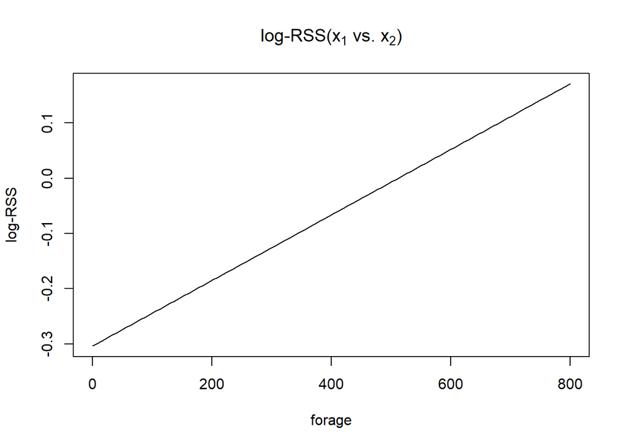

```r
plot(logRSS)
```

But if we want more control, we can use ggplot with the ‘df’ data.frame.

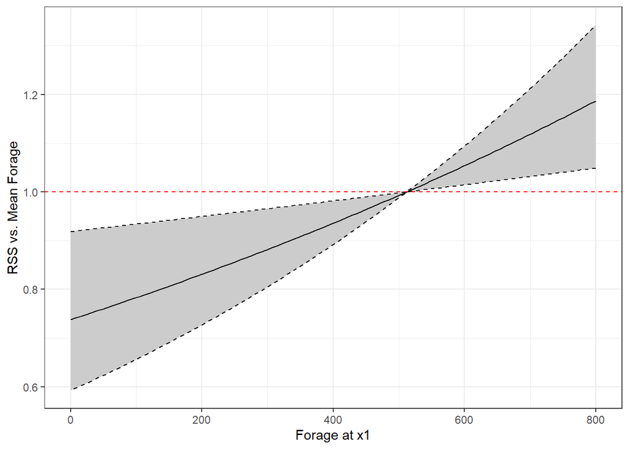

```r
ggplot(logRSS$df, aes(x = forage_x1, y = exp(log_rss),
                      ymin = exp(lwr), ymax = exp(upr))) +
  geom_ribbon(color = "black", fill = "gray80", linetype = "dashed") +
  geom_line() +
  geom_hline(yintercept = 1, color = "red", linetype = "dashed") +
  xlab("Forage at x1") +
  ylab("RSS vs. Mean Forage") +
  theme_bw()
```